# MultiGWAS report for full GWAS model

MultiGWAS executes two types of GWAS models: Full and Naive. The Full model with control for population structure and individual relatedness and the Naive model without any control. In both models, users can apply different control quality filters for the genomic data.

# 1 Input Parameters

The following table shows the current input parameters specified by the user in the configuration file:

| PARAMETER | VALUE |
| --- | --- |
| Genotype filename | example-genotype-tetra-gwaspoly-ACGT.csv |
| Phenotype filename | tuber_shape.csv |
| Genotype format (gwaspoly, matrix, vcf, updog, fitpoly) | gwaspoly |
| Map filename |  |
| Ploidy (4 or 2) | 4 |
| Significance level (Genome-wide significance level) | 0.05 |
| Correction method (Bonferroni or FDR) | Bonferroni |
| GWAS model (Full or Naive) | full |
| Filtering (TRUE or FALSE) | TRUE |
| MIND Filter (Individual with missing genotype) | 0.1 |
| GENO Filter (SNPs with missing genotype) | 0.1 |
| MAF Filter (Minor allele frequency) | 0.01 |
| HWE Filter (Hardy-Weinberg test) | 1e-10 |
| R2 LD (Linkage disequilibrium threshold) | 0.9 |
| GWAS Tools | gwaspoly shesis gapit tassel |
| nBest (Number of top SNPs to be reported) | 10 |

# 2 SNPs in Linkage Disequilibrium above $R^2$ = 0.9

```
## The following table shows the SNPs in Linkage Disequilibrium
```

| LD_SNP | SNP1 | SNP2 | R2 |
| --- | --- | --- | --- |
| LD_SNP_1 | c1_8019 | c2_25471 | 0.9284082 |
| LD_SNP_2 | c2_45611 | c2_45606 | 1.0000000 |

## 2.1 Venn diagram for SNPs in LD

The Venn diagram shows SNPs in LD named as ‘LD_SNP_XX’. Shared SNPs appear in the intersection areas of the diagram.

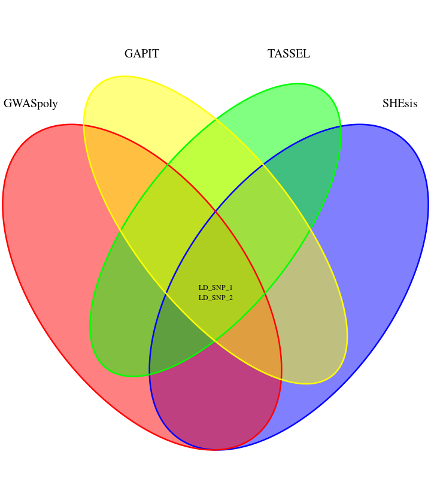

# 3 Best-ranked SNPs

This section shows a table and a Venn diagram for the best ranked SNPs (For this report, N=10). The configuration file allows defining the parameter N.

## 3.1 Table of best-ranked SNPs

The following table shows the associations between SNPs and the trait as transformed p-values to scores as -log 10 (p-value) sorted from the highest to the lowest scores based on each tool analysis and the model selected (Full or Naive). Each SNP has its associated information, such as the chromosome, position in the genome, and name. Also, based on the threshold calculated by a multiple testing correction (i.e., Bonferroni or FDR), the table marks the significance of each SNP as a TRUE or FALSE.

| TOOL | MODEL | GC | SNP | CHROM | POSITION | PVALUE | SCORE | THRESHOLD | SIGNIFICANCE |
| --- | --- | --- | --- | --- | --- | --- | --- | --- | --- |
| GWASpoly | additive | 1.016 | c1_8019 | 10 | 48863165 | 0.000007 | 5.1800 | 4.6500 | TRUE |
| GWASpoly | additive | 1.016 | c2_25471 | 10 | 48808404 | 0.000015 | 4.8200 | 4.6500 | TRUE |
| GWASpoly | additive | 1.016 | c2_45611 | 10 | 48203431 | 0.000132 | 3.8800 | 4.6500 | FALSE |
| GWASpoly | additive | 1.016 | c2_549 | 9 | 16527499 | 0.000151 | 3.8200 | 4.6500 | FALSE |
| GWASpoly | additive | 1.016 | c2_45606 | 10 | 48218826 | 0.000174 | 3.7600 | 4.6500 | FALSE |
| GWASpoly | additive | 1.016 | c2_9925 | 1 | 81410256 | 0.000589 | 3.2300 | 4.6500 | FALSE |
| GWASpoly | additive | 1.016 | c1_8021 | 10 | 48862950 | 0.000661 | 3.1800 | 4.6500 | FALSE |
| GWASpoly | additive | 1.016 | c2_26504 | 9 | 21610960 | 0.001349 | 2.8700 | 4.6500 | FALSE |
| GWASpoly | additive | 1.016 | c1_3894 | 1 | 71421420 | 0.001549 | 2.8100 | 4.6500 | FALSE |
| GWASpoly | additive | 1.016 | c2_22187 | 11 | 40777537 | 0.001698 | 2.7700 | 4.6500 | FALSE |
| SHEsis | additive | 3.970 | c1_8019 | 10 | 48863165 | 0.000000 | 11.4559 | 5.3836 | TRUE |
| SHEsis | additive | 3.970 | c1_13526 | 10 | 48020996 | 0.000000 | 10.7986 | 5.3836 | TRUE |
| SHEsis | additive | 3.970 | c2_53380 | 1 | 70371898 | 0.000000 | 10.6073 | 5.3836 | TRUE |
| SHEsis | additive | 3.970 | c2_25471 | 10 | 48808404 | 0.000000 | 9.6253 | 5.3836 | TRUE |
| SHEsis | additive | 3.970 | c2_54811 | 1 | 46270954 | 0.000000 | 9.5467 | 5.3836 | TRUE |
| SHEsis | additive | 3.970 | c2_45606 | 10 | 48218826 | 0.000000 | 8.2013 | 5.3836 | TRUE |
| SHEsis | additive | 3.970 | c2_11977 | 5 | 3515956 | 0.000000 | 8.1656 | 5.3836 | TRUE |
| SHEsis | additive | 3.970 | c1_8021 | 10 | 48862950 | 0.000000 | 7.9872 | 5.3836 | TRUE |
| SHEsis | additive | 3.970 | c1_16351 | 10 | 48761642 | 0.000000 | 7.9666 | 5.3836 | TRUE |
| SHEsis | additive | 3.970 | c2_45611 | 10 | 48203431 | 0.000000 | 7.7878 | 5.3836 | TRUE |
| GAPIT | additive | 0.902 | c2_25471 | 10 | 48808404 | 0.000346 | 3.4613 | 4.6847 | FALSE |
| GAPIT | additive | 0.902 | c1_16001 | 10 | 47539878 | 0.000397 | 3.4007 | 4.6847 | FALSE |
| GAPIT | additive | 0.902 | c2_45611 | 10 | 48203431 | 0.000408 | 3.3892 | 4.6847 | FALSE |
| GAPIT | additive | 0.902 | c2_45606 | 10 | 48218826 | 0.000408 | 3.3892 | 4.6847 | FALSE |
| GAPIT | additive | 0.902 | c1_8019 | 10 | 48863165 | 0.000955 | 3.0202 | 4.6847 | FALSE |
| GAPIT | additive | 0.902 | c1_8021 | 10 | 48862950 | 0.001170 | 2.9320 | 4.6847 | FALSE |
| GAPIT | additive | 0.902 | c1_16351 | 10 | 48761642 | 0.001178 | 2.9290 | 4.6847 | FALSE |
| GAPIT | additive | 0.902 | c1_329 | 10 | 565197 | 0.001822 | 2.7394 | 4.6847 | FALSE |
| GAPIT | additive | 0.902 | c1_11144 | 6 | 56135600 | 0.003267 | 2.4858 | 4.6847 | FALSE |
| GAPIT | additive | 0.902 | c1_5995 | 7 | 55209778 | 0.003341 | 2.4762 | 4.6847 | FALSE |
| TASSEL | additive | 0.991 | c1_14512 | 1 | 43409359 | 0.002967 | 2.5277 | 4.2695 | FALSE |
| TASSEL | additive | 0.991 | c1_10202 | 4 | 70396887 | 0.005245 | 2.2803 | 4.2695 | FALSE |
| TASSEL | additive | 0.991 | c2_46195 | 1 | 64259758 | 0.005269 | 2.2783 | 4.2695 | FALSE |
| TASSEL | additive | 0.991 | c1_16001 | 10 | 47539878 | 0.005427 | 2.2655 | 4.2695 | FALSE |
| TASSEL | additive | 0.991 | c2_45606 | 10 | 48218826 | 0.006296 | 2.2009 | 4.2695 | FALSE |
| TASSEL | additive | 0.991 | c2_45611 | 10 | 48203431 | 0.006785 | 2.1685 | 4.2695 | FALSE |
| TASSEL | additive | 0.991 | c2_3680 | 11 | 39908878 | 0.007068 | 2.1507 | 4.2695 | FALSE |
| TASSEL | additive | 0.991 | c1_3894 | 1 | 71421420 | 0.008131 | 2.0898 | 4.2695 | FALSE |
| TASSEL | additive | 0.991 | c2_40954 | 1 | 63756796 | 0.008774 | 2.0568 | 4.2695 | FALSE |
| TASSEL | additive | 0.991 | c2_25471 | 10 | 48808404 | 0.008997 | 2.0459 | 4.2695 | FALSE |

## 3.2 Venn diagram of best-ranked SNPs

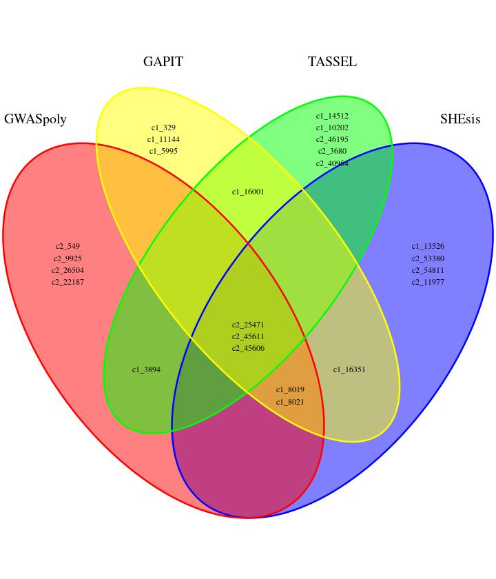

# 4 Significant SNPs

This section shows a table and a Venn diagram for the signifcative SNPs (score is above the significance threshold for each tool).

## 4.1 Table of significant SNPs

The following table shows the associations between SNPs and the trait as transformed p-values to scores as -log 10 (p-value) sorted from the highest to the lowest scores based on each tool analysis and the model selected (Full or Naive). Each SNP has its associated information, such as the chromosome, position in the genome, and name.

| TOOL | MODEL | GC | SNP | CHROM | POSITION | PVALUE | SCORE | THRESHOLD | SIGNIFICANCE |
| --- | --- | --- | --- | --- | --- | --- | --- | --- | --- |
| GWASpoly | additive | 1.016 | c1_8019 | 10 | 48863165 | 7.0e-06 | 5.1800 | 4.6500 | TRUE |
| GWASpoly | additive | 1.016 | c2_25471 | 10 | 48808404 | 1.5e-05 | 4.8200 | 4.6500 | TRUE |
| SHEsis | additive | 3.970 | c1_8019 | 10 | 48863165 | 0.0e+00 | 11.4559 | 5.3836 | TRUE |
| SHEsis | additive | 3.970 | c1_13526 | 10 | 48020996 | 0.0e+00 | 10.7986 | 5.3836 | TRUE |
| SHEsis | additive | 3.970 | c2_53380 | 1 | 70371898 | 0.0e+00 | 10.6073 | 5.3836 | TRUE |
| SHEsis | additive | 3.970 | c2_25471 | 10 | 48808404 | 0.0e+00 | 9.6253 | 5.3836 | TRUE |
| SHEsis | additive | 3.970 | c2_54811 | 1 | 46270954 | 0.0e+00 | 9.5467 | 5.3836 | TRUE |
| SHEsis | additive | 3.970 | c2_45606 | 10 | 48218826 | 0.0e+00 | 8.2013 | 5.3836 | TRUE |
| SHEsis | additive | 3.970 | c2_11977 | 5 | 3515956 | 0.0e+00 | 8.1656 | 5.3836 | TRUE |
| SHEsis | additive | 3.970 | c1_8021 | 10 | 48862950 | 0.0e+00 | 7.9872 | 5.3836 | TRUE |
| SHEsis | additive | 3.970 | c1_16351 | 10 | 48761642 | 0.0e+00 | 7.9666 | 5.3836 | TRUE |
| SHEsis | additive | 3.970 | c2_45611 | 10 | 48203431 | 0.0e+00 | 7.7878 | 5.3836 | TRUE |

## 4.2 Venn diagram of significant SNPs

The Venn diagram shows the significant SNPs that are either unique or shared by the four software. Shared SNPs appear in the intersection areas of the diagram.

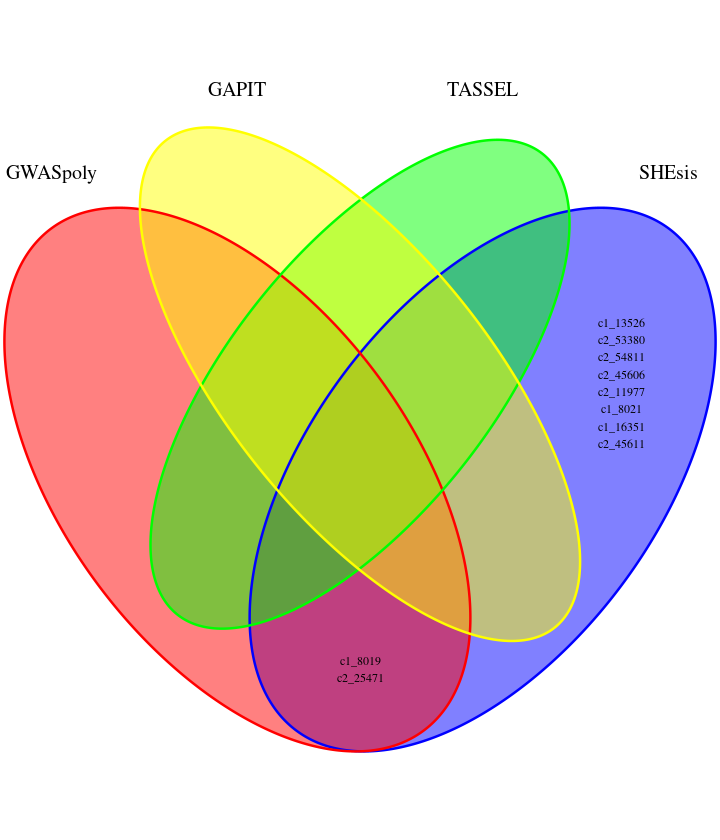

# 5 Manhattan and QQ plots

The QQ plot plots the observed (black dot lines) vs. expected -log 10 (p-value) (red line).

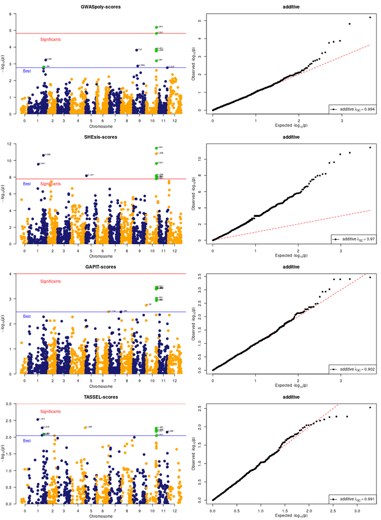

# 6 Chord diagrams for SNPs by chromosome

Chord diagrams are used in MultiGWAS to highlight nearby SNPs found on the same chromosome. These SNPs may have been identified simultaneously by multiple GWAS packets, which can be interpreted as a possible strong association, as in the Manhattan charts, where these associations form clean peaks with multiple SNPs displaying the same signal.

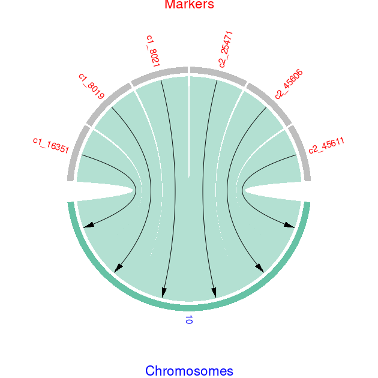